# Monte Carlo Simulation and Option Pricing with Stochastic Processes

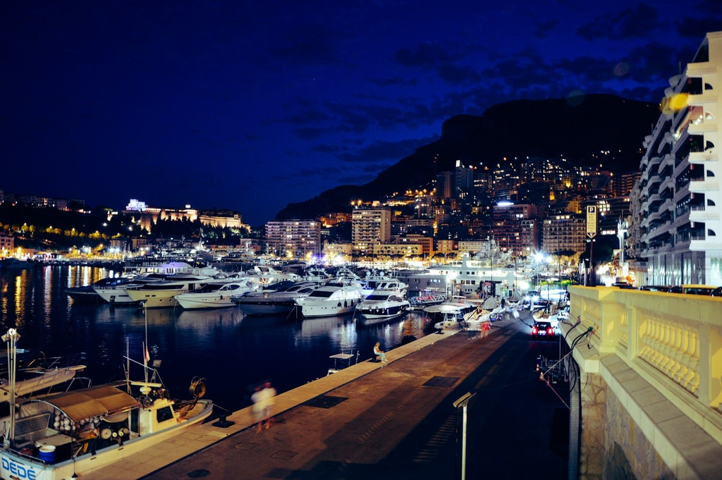

- Monte Carlo simulation a computational method that utilies random numbers. It is among the most important numerical techniques in finance, this mainly stems from the fact it is the most flexible method when it comes to the evaluating integrals.
- Stochatic proccesses are equations with integrals that have an element of randomized input that can be used to describe the random movement of certain phenomena over time, in this option and stock values!
- Utilsing Monte Carlo simulation we can evaluate these stochastic procces to be able to value financial instruments!

# step 1 - Random number generation

Stochastic proccess require random number input, these random numbers can be drawn from a variety of distributions dependent upon the process.

Put simplistically we can evaluate a stochastic process integral by inputting a vector of random numbers drawn from the descriptive distribution! Each random number drawn represents a simulation of how the stochastic process which describe our financial instrument of interest over one time interval.

Below I demonstrate how python can be used to draw random numbers from both a unifrom and standard distribution and how these numbers can be shaped into arrays to feed our multiple simulations and mutliple time intervals we may want to interrogate.

[figure not shown]

```python
import math
import numpy as np
import numpy.random as random
import matplotlib.pyplot as plt

plt.style.use('seaborn')

#fixes the seed value
random.seed(1)
# fixes the number of decimal places returns by the numpy functions, suppress gets rid of scientific format
np.set_printoptions(precision=3, suppress=True)

#rand() by default returns uniformly distibuted numbers between 0 and 1, inputting a single number returns a 1d array of that size fo random numbers
random.rand(10)

#two digits returns a 2d array of the equivalent shape
random.rand(10,2)

#lower limit
a = -0.01
#upper limit
b=0.1

# we can translate the numbers to be between limits as follows
uniform_random_numbers = random.rand(1000)*(b-a)+a
#generate 10 standard normally distributed numbers
SD_random_numbers = random.standard_normal(1000)

fig, (ax1, ax2) = plt.subplots(1,2,figsize=(14,6))
ax1.hist(uniform_random_numbers , bins=30, color = 'r')
ax1.set_title()

ax2.hist(SD_random_numbers, bins=30)
```